# Exercises 10 - t-tests and ANOVA

# Exercise 1

We will start by trying to answer the question of whether women earned less on average than men in 1985. We will use the CPS85 dataset in mosaicData to try to answer this question. The variables we are interested in are `sex` and `wage`. If you were to set up a statistical test to understand the difference in wages between men and women, what would your null and alternative hypotheses be?

- $H_o:$ Then null hypothesis is there is relationship of women earning with respect to that of men in 1985
- $H_A:$ The alternate hypothesis is women earned less on average than men in 1985

Load in the packages you will use and look at the top few rows of the `CPS85` dataset.

```r
library(ggplot2)
library(mosaicData)
library(dplyr)
library(mosaic)
library(tidyr)
```

Create a visualization (or two) of the data that helps you see whether there is a difference in the wages of women and men.

```r
# Viewing the CPS85 dataset at first to see the names of the variables and other things too
head(CPS85)
```

```
##   wage educ race sex hispanic south married exper union age   sector
## 1  9.0   10    W   M       NH    NS Married    27   Not  43    const
## 2  5.5   12    W   M       NH    NS Married    20   Not  38    sales
## 3  3.8   12    W   F       NH    NS  Single     4   Not  22    sales
## 4 10.5   12    W   F       NH    NS Married    29   Not  47 clerical
## 5 15.0   12    W   M       NH    NS Married    40 Union  58    const
## 6  9.0   16    W   F       NH    NS Married    27   Not  49 clerical
```

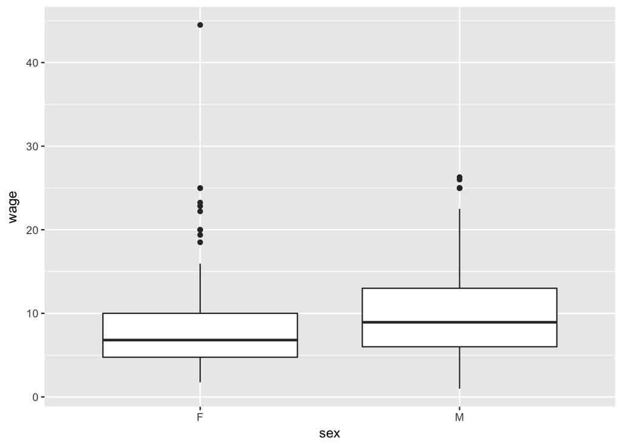

```r
# Boxplot'd be the perfect fit to visualize the difference in the wages with respect to sex
ggplot(data = CPS85, mapping = aes(x = sex, y = wage)) +
        geom_boxplot()
```

Calculate the mean wage for women and men in the dataset:

```r
summary_data <- CPS85 %>%
        group_by(sex) %>%
        summarise(mean = mean(wage))

# viewing whether mean was calculated or not
summary_data
```

```
## # A tibble: 2 × 2
##      sex     mean
##   <fctr>    <dbl>
## 1      F 7.878857
## 2      M 9.994913
```

The difference between the means is 2.116056

```r
difference_between_means <- summary_data$mean[2] - summary_data$mean[1]

# this is the difference between means
difference_between_means
```

```
## [1] 2.116056
```

Is this difference large enough to be meaningful? i.e. would a difference this large 2.116056 actually be worthwhile to examine? (For example a difference in the averages of $0.05 per hour could be statistically significant but the difference is not meaningful in terms of actual earnings.)

Set up a randomization simulation to simulate the null hypothesis.

```r
nruns = 1000

simulation_results <- do(nruns)*{
        summary = data.frame(sex=shuffle(CPS85$sex), wage=CPS85$wage) %>%
                 group_by(sex) %>%
                 summarise(mean=mean(wage))
                 difference_between_means_after_simulation = summary$mean[2]-summary$mean[1]
}

# let's view simulation_results
head(simulation_results)
```

```
##       result
## 1  0.1457506
## 2 -0.1437052
## 3 -0.6500644
## 4 -0.6910920
## 5  0.5931325
## 6 -0.6267601
```

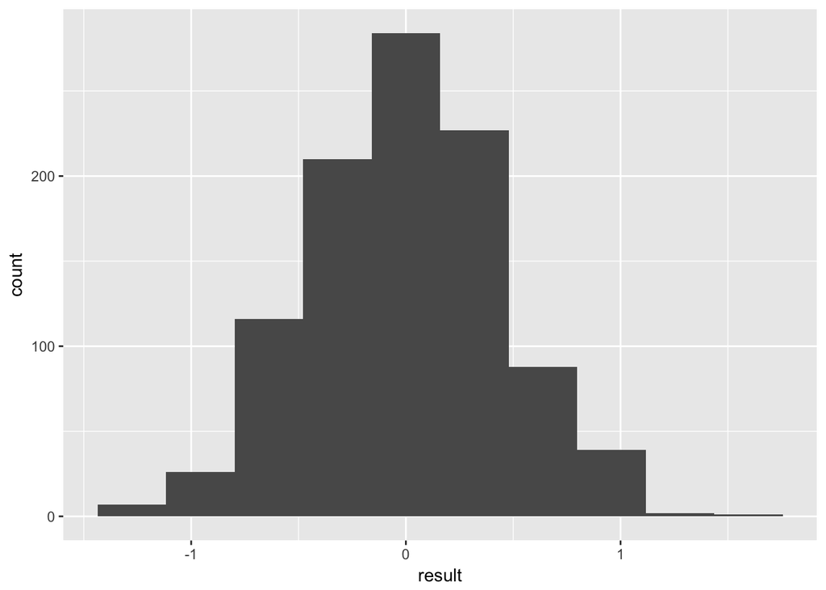

```r
# let's visualize our simulation
ggplot(data=simulation_results, aes(x=result)) +
        geom_histogram(bins = 10)
```

Use the results to caluclate a p-value for the results using the randomization simulation.

```r
# For calculating P-value, we would like to see how many of the random reshufflings had a difference of 2.116056 or more.
# and then find it's proportion by dividing it by nruns (1000)


result <- simulation_results %>%
        summarise(
                count(result >= 2.116056)/nruns
        )

# OR we can also do it in different way too (shown by Katie)
# result= simulation_results %>%
#         filter(result >= 2.116056) %>%
#         summarize(count=n()/nruns)

result
```

```
##   count(result >= 2.116056)/nruns
## 1                               0
```

What conclusions can you draw from these results?

This is very unlikely (p = 2*0 (0) < 0.05) so we reject the null hypothesis and conclude that women earned less on average than men in 1985.

Now run a traditional t-test.

```r
t.test(data = CPS85, wage~sex)
```

```
##
##  Welch Two Sample t-test
##
## data:  wage by sex
## t = -4.8853, df = 530.55, p-value = 1.369e-06
## alternative hypothesis: true difference in means is not equal to 0
## 95 percent confidence interval:
##  -2.966949 -1.265164
## sample estimates:
## mean in group F mean in group M
##        7.878857        9.994913
```

Explain your results as you might in a project writeup for a statistically literate audience.

How do the results of the t-test and of the randomization simulation differ?

# Exercise 2

In this exercise we will analyze the data from an experiment performed to compare the yields of 30 plants which were divided into 3 groups: two treatments and a control. The yield is quantified by measuring the weight of the dried plants at the end of the experiment. This dataset is stored in `PlantGrowth` within the package `datasets`.

We will test the hypothesis that neither treatment has any effect on the yield of the plant.

What would you null and alternative hypotheses be?

Load in the packages you will use and look at the top few rows of the `PlantGrowth` dataset.

Create a visualization (or two) of the data that helps you see whether there is a difference in the yields of the plants in the three treatment groups.

Create a summary table that shows the mean weight of plants in each group. Make it so that the resulting table is displayed in your knit file.

At this point you should ask yourself if the differences between the means are large enough to be meaningful? Underlying idea: We might not even care that a difference is statistically significant if the difference is so small that it doesn’t really matter within the context of the problem. Note: the answer to this question is very dependent on the system you are studying and the units involved. Here you might not have enough information about the system and dried plant weights to know whether the difference between the means is meaningful.

Now run an ANOVA.

Explain your results as you might in a project writeup for a statistically literate audience.

# Optional exercises:

Use the cited dataset to answer the stated question or test the stated hypothesis using whatever methods are most appropriate.

**chi-square**:

- survey{MASS}: Test the hypothesis that the students smoking habit is independent of their exercise level at $\alpha = .05$ significance level.
- housetasks data sets from STHDA: http://www.sthda.com/sthda/RDoc/data/housetasks.txt: `housetasks <- read.delim("http://www.sthda.com/sthda/RDoc/data/housetasks.txt", row.names = 1)` Restrict the dataset to only Repairs, Holidays, and Dinner. Test the hypothesis that who does a task within a household is independent of the task that is being completed (for the straight cis-gendered couples sampled).
- Titanic{datasets}: Test the hypothesis that a passenger’s survival is independent of their Class.

**T-test**:

- crabs{MASS}: Test the hypothesis that the mean body depth (`BD`) is the same for both male and female crabs.
- mtcars{datasets}: Test the hypothesis that the the fuel efficiency of a car (`mpg`) and the transmission type of the car (`am`, 0=automatic and 1=manual) are independent of each other.
- ToothGrowth{datasets}: Test the hypothesis that the choice of supplement (`supp`) does not affect the tooth growth (`len`) of guinea pigs (ignore the potential role that dose may play for this exercise).
- immer{MASS}: Is there a difference in the yield from 1931 to 1932? (Ignore all other factors for now)

**ANOVA**:

- InsectSprays{datasets}: Test the hypothesis that the spray treatments did not affect the mean number of insect counted.
- iris{datasets}: Are there significant differences in the `Petal.Length` between the three `Species`?
- Medication alertness data: Are there significant differences in the `Alertness` of study participants based on the `Dosage`? Use the following command to get the data into R: `MedAlertness=read.table("http://personality-project.org/r/datasets/R.appendix1.data",header=T)`
- immer{MASS}: Test the hypothesis that the change in yield from 1931 to 1932 was independent of the variety of barley. As a followup: if there is a difference, which types of barley are significantly different from which others?